# Lesson 2 - ggplot2

### Modifying Aesthetics

Now lets configure another aesthetic of `geom_point()` by specifying a color for the points, using the argument `color`. Lets use the color `"steelblue"`.

#### Activity

Add `color = "steelblue"` as an additional argument to `aes()` within geom_point

What happens?

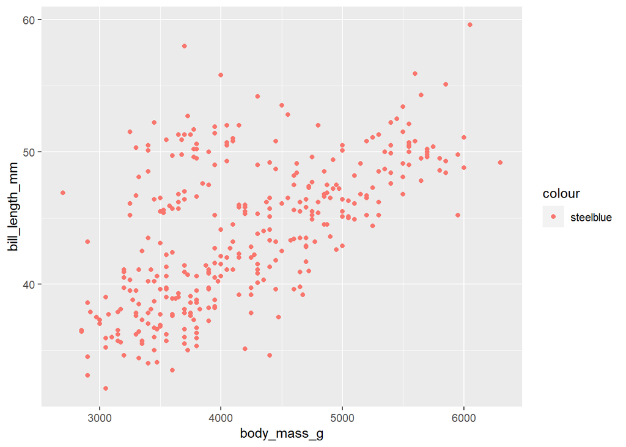

```r
ggplot(data = penguins) +
  geom_point(aes(x = body_mass_g,
                 y = bill_length_mm,
                 color = "steelblue"))
```

The points are colored red, even though we explicitly specified that they be *steelblue*. This unexpected behaviour is related to how ggplot2 handles aesthetic arguments. Those that are defined within `aes()` map data to an aesthetic using a **scale**.

Those that are defined outside of `aes()` are set to a fixed value. Let’s try again, but move `color = "steelblue"` outside of `aes()`.

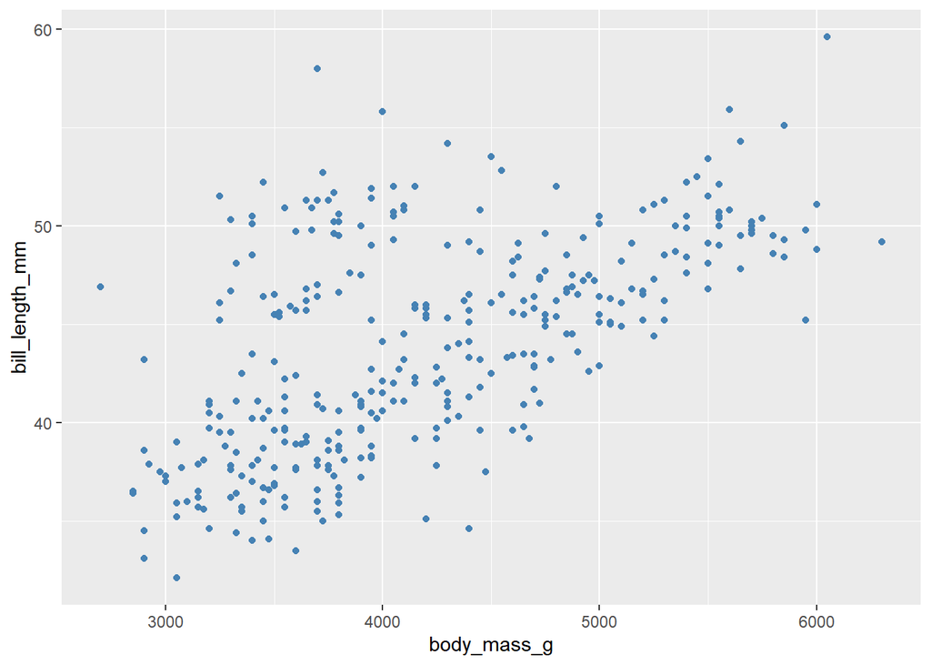

```r
ggplot(data = penguins) +
  geom_point(aes(x = body_mass_g,
                 y = bill_length_mm),
                 color = "steelblue")
```

That produces the result we expected. Remember, if you want to set an aesthetic to a fixed value (such as setting points to the color steelblue) then do it **outside** of `aes()`. If you want to map some variable of your data to an aesthetic automatically, then do it **inside** `aes()`

Let’s try mapping the species variable to color:

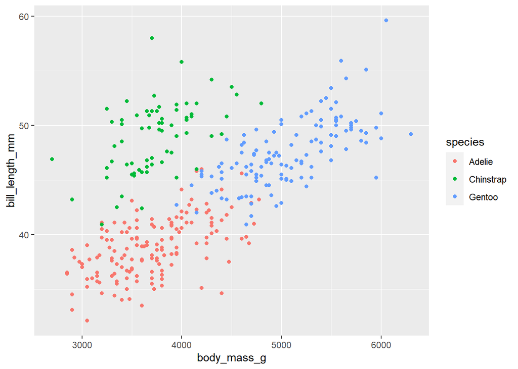

```r
ggplot(data = penguins) +
  geom_point(aes(x = body_mass_g,
                 y = bill_length_mm,
                 color = species))
```

This produces points colored by species, and automatically creates an appropriately named legend. The individual points look a little small, so let’s increase their size.

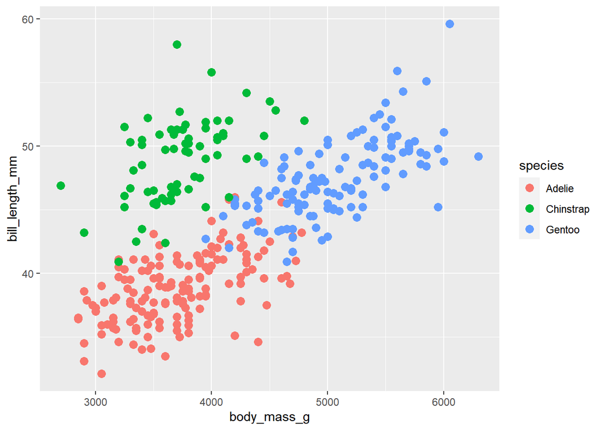

```r
ggplot(data = penguins) +
  geom_point(aes(x = body_mass_g,
                 y = bill_length_mm,
                 color = species),
             size = 3)
```

Now let’s add transparency so that we can see points being occluded by other points.

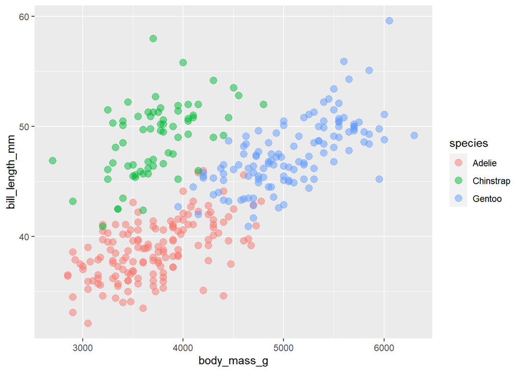

```r
ggplot(data = penguins) +
  geom_point(aes(x = body_mass_g,
                 y = bill_length_mm,
                 color = species),
             size = 3,
             alpha = .5)
```

### Using RColorBrewer Palettes

This is looking better, but the default use of red and green is not colorblind friendly. Let’s correct this by using a palette from RColorBrewer. Fortunately, with ggplot2 we can pass the palette directly in to ggplot2:

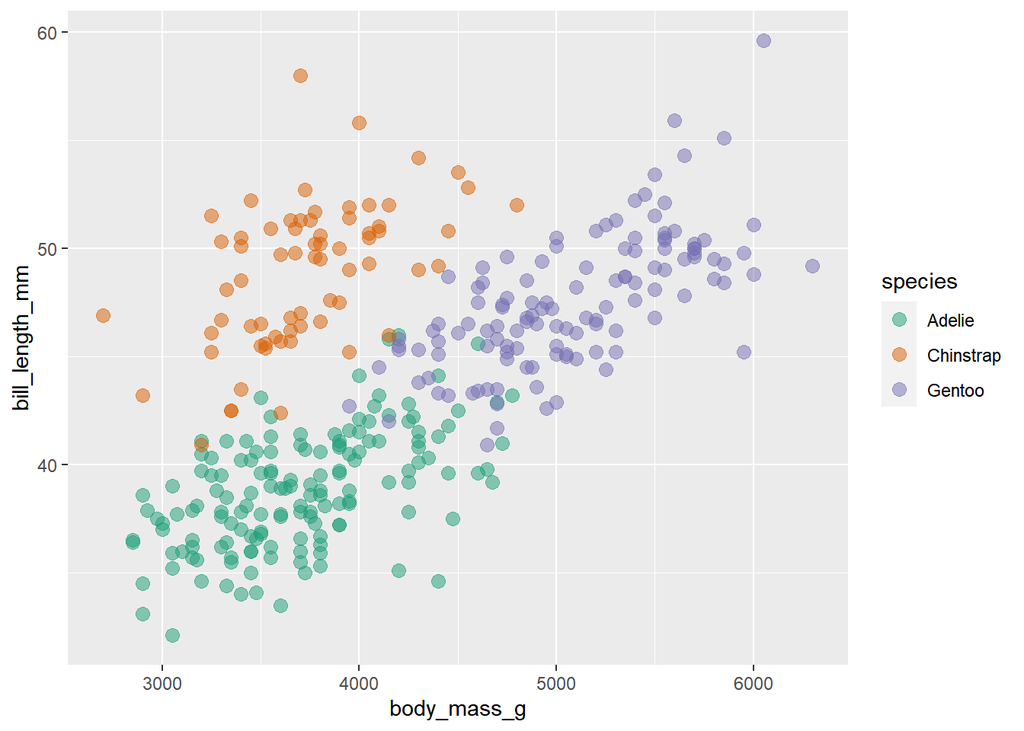

```r
ggplot(data = penguins) +
  geom_point(aes(x = body_mass_g,
                 y = bill_length_mm,
                 color = species),
             size = 3,
             alpha = .5) +
  scale_color_brewer(palette = "Dark2")
```

Now let’s clean up those axis labels:

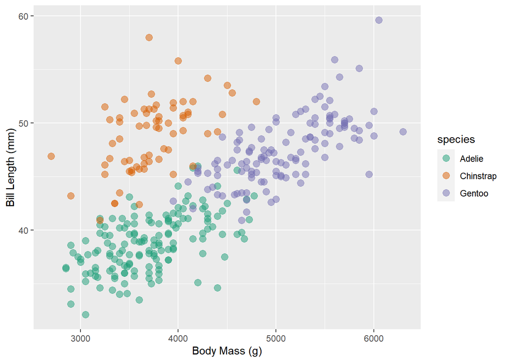

```r
ggplot(data = penguins) +
  geom_point(aes(x = body_mass_g,
                 y = bill_length_mm,
                 color = species),
             size = 3,
             alpha = .5) +
  scale_color_brewer(palette = "Dark2") +
  xlab("Body Mass (g)") +
  ylab("Bill Length (mm)")
```

### Themes

Remember, never trust the defaults. Although ggplot2 plots look much nicer than base R, that does not mean they are ready for publication. There are a few things we can do to clean this plot up. Let’s start my removing that unnecessary grey background. We can do this easily by applying the **minimal** theme:

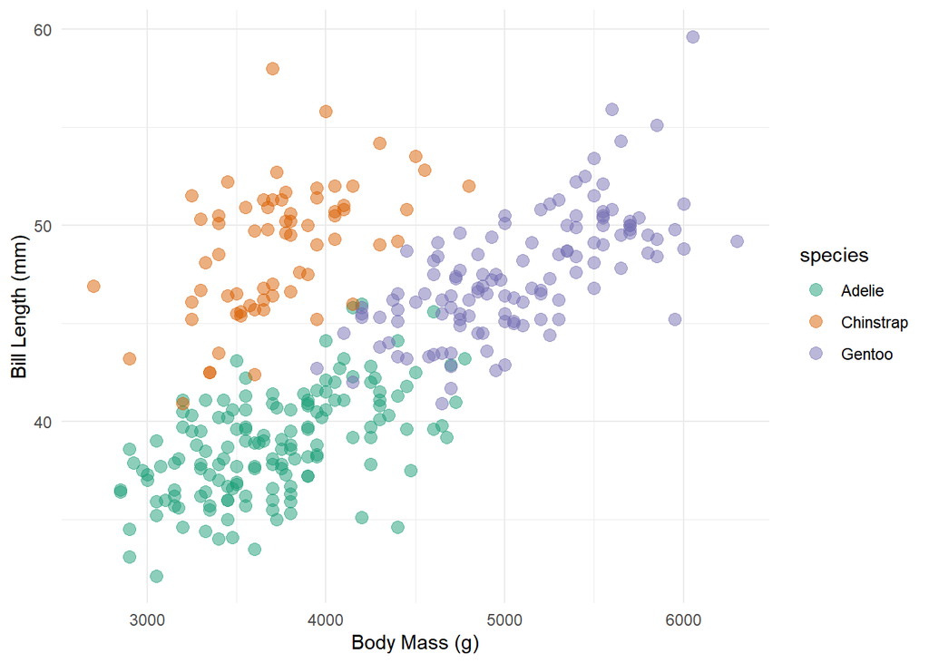

```r
ggplot(data = penguins) +
  geom_point(aes(x = body_mass_g,
                 y = bill_length_mm,
                 color = species),
             size = 3,
             alpha = .5) +
  scale_color_brewer(palette = "Dark2") +
  xlab("Body Mass (g)") +
  ylab("Bill Length (mm)") +
  theme_minimal()
```

Lets increase the size of our x and y label font and axis label font to make the labels more visible. To do this, we will need to manually modify the theme:

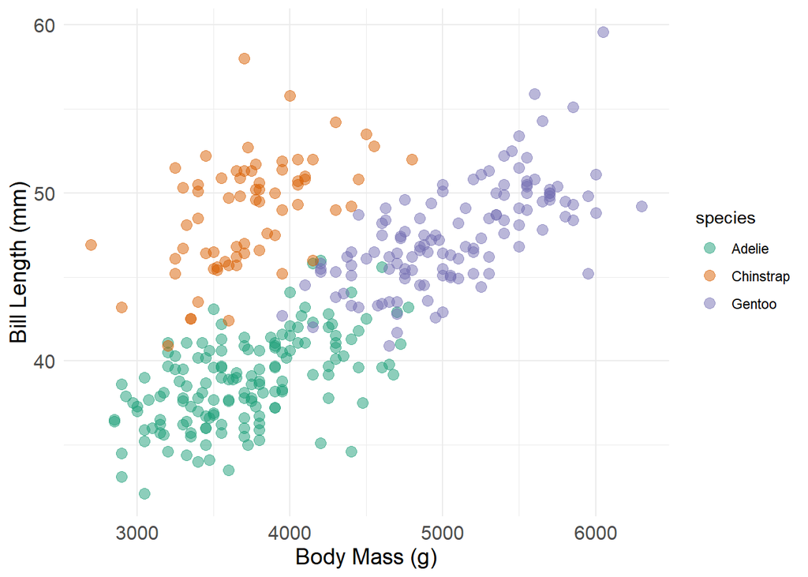

```r
ggplot(data = penguins) +
  geom_point(aes(x = body_mass_g,
                 y = bill_length_mm,
                 color = species),
             size = 3,
             alpha = .5) +
  scale_color_brewer(palette = "Dark2") +
  xlab("Body Mass (g)") +
  ylab("Bill Length (mm)") +
  theme_minimal() +
  theme(axis.title.x = element_text(size = 14),
        axis.title.y = element_text(size = 14),
        axis.text = element_text(size = 12))
```

#### Activity

What happens when you switch the positions of `theme()` and `theme_minimal()`?

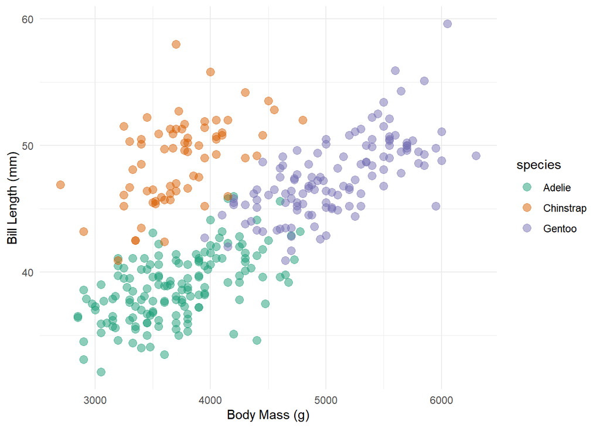

```r
ggplot(data = penguins) +
  geom_point(aes(x = body_mass_g,
                 y = bill_length_mm,
                 color = species),
             size = 3,
             alpha = .5) +
  scale_color_brewer(palette = "Dark2") +
  xlab("Body Mass (g)") +
  ylab("Bill Length (mm)") +
  theme(axis.title.x = element_text(size = 14),
        axis.title.y = element_text(size = 14),
        axis.text = element_text(size = 12)) +
  theme_minimal()
```

All of our modifications are lost. This is because the order of our theme matters. Because we call `theme_minimal()` after `theme()`, we overwrite any changes we made with the defaults from `theme_minimal()`. If we want to modify how `theme_minimal()` looks we do it after calling `theme_minimal()`.

### Creating Titles (and Subtitles)

Now let’s complete our plot with a title and subtitle:

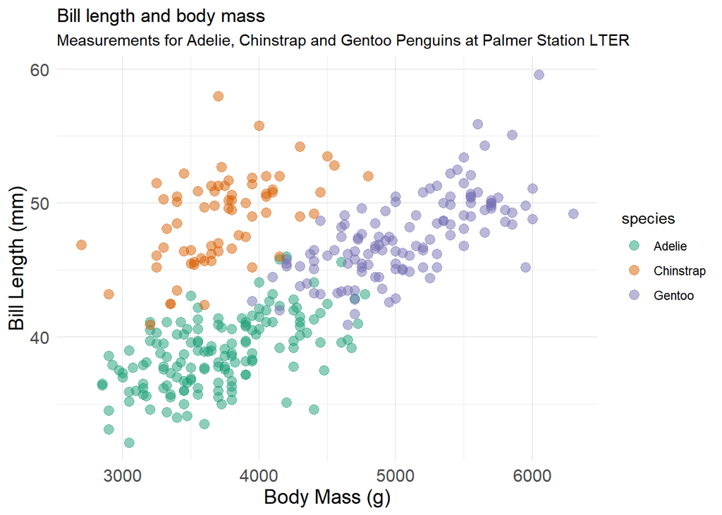

```r
ggplot(data = penguins) +
  geom_point(aes(x = body_mass_g,
                 y = bill_length_mm,
                 color = species),
             size = 3,
             alpha = .5) +
  scale_color_brewer(palette = "Dark2") +
  xlab("Body Mass (g)") +
  ylab("Bill Length (mm)") +
  labs(title = "Bill length and body mass",
       subtitle = "Measurements for Adelie, Chinstrap and Gentoo Penguins at Palmer Station LTER") +
  theme_minimal() +
  theme(axis.title.x = element_text(size = 14),
        axis.title.y = element_text(size = 14),
        axis.text = element_text(size = 12))
```

### Modifying Legends

Now lets cleanup our legend. The species are made clear in the subtitle, so we can remove the legend title.

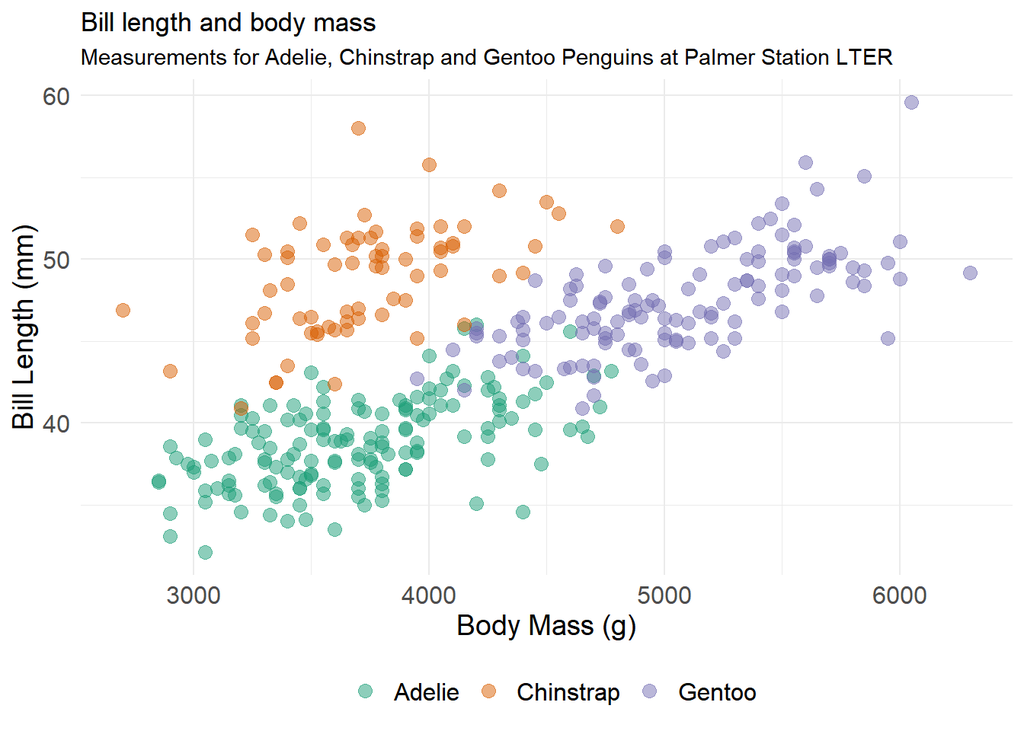

```r
ggplot(data = penguins) +
  geom_point(aes(x = body_mass_g,
                 y = bill_length_mm,
                 color = species),
             size = 3,
             alpha = .5) +
  scale_color_brewer(palette = "Dark2") +
  xlab("Body Mass (g)") +
  ylab("Bill Length (mm)") +
  labs(title = "Bill length and body mass",
       subtitle = "Measurements for Adelie, Chinstrap and Gentoo Penguins at Palmer Station LTER") +
  theme_minimal() +
  theme(axis.title.x = element_text(size = 14),
        axis.title.y = element_text(size = 14),
        axis.text = element_text(size = 12),
        legend.title = element_blank(),
        legend.text = element_text(size = 12),
        legend.position = "bottom")
```

### Adding Statistical Summaries

Now let’s add a statistical summary. we will use the `geom_smooth()` layer to add fit a smoothed line to each group, along with confidence intervals. The default method (when there is less than 1000 points) is locally estimated scatterplot smoothing (LOESS) which is a generalization of a moving average and polynomial regression.

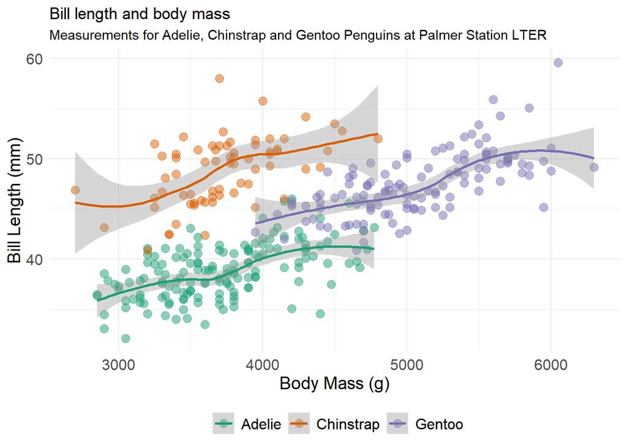

```r
ggplot(data = penguins) +
  geom_point(aes(x = body_mass_g,
                 y = bill_length_mm,
                 color = species),
             size = 3,
             alpha = .5) +
  geom_smooth(aes(x = body_mass_g,
                  y = bill_length_mm,
                  color = species)) +
  scale_color_brewer(palette = "Dark2") +
  xlab("Body Mass (g)") +
  ylab("Bill Length (mm)") +
  labs(title = "Bill length and body mass",
       subtitle = "Measurements for Adelie, Chinstrap and Gentoo Penguins at Palmer Station LTER") +
  theme_minimal() +
  theme(axis.title.x = element_text(size = 14),
        axis.title.y = element_text(size = 14),
        axis.text = element_text(size = 12),
        legend.title = element_blank(),
        legend.text = element_text(size = 12),
        legend.position = "bottom")
```

### Local vs Global Aesthetics

Do you notice how we had to repeat the `aes()` arguments for `geom_point()` and `geom_smooth()`? This seems redundant. Right now we declare the aesthetics every time we add a new geom layer, but if the aesthetics are the same for every layer, we can just declare them once. Aesthetics declared in `ggplot()` are global, and apply to every layer. Aesthetics applied to a specific geom layer, such as `geom_point()` are local, and only apply to that geom layer.

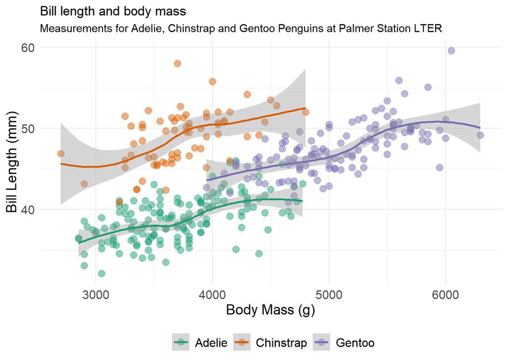

```r
ggplot(data = penguins,
       aes(x = body_mass_g,
           y = bill_length_mm,
           color = species)) +
  geom_point(size = 3,
             alpha = .5) +
  geom_smooth() +
  scale_color_brewer(palette = "Dark2") +
  xlab("Body Mass (g)") +
  ylab("Bill Length (mm)") +
  labs(title = "Bill length and body mass",
       subtitle = "Measurements for Adelie, Chinstrap and Gentoo Penguins at Palmer Station LTER") +
  theme_minimal() +
  theme(axis.title.x = element_text(size = 14),
        axis.title.y = element_text(size = 14),
        axis.text = element_text(size = 12),
        legend.title = element_blank(),
        legend.text = element_text(size = 12),
        legend.position = "bottom")
```

### Facets

If our data is too dense, we can split it into small multiples using facets:

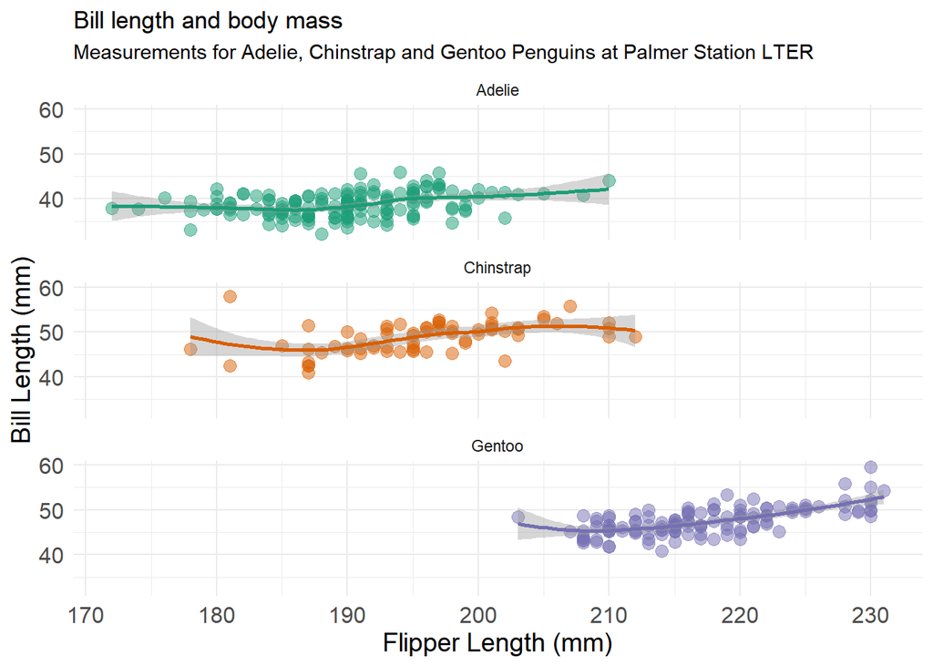

```r
ggplot(data = penguins,
       aes(x = flipper_length_mm,
           y = bill_length_mm,
           color = species)) +
  geom_point(size = 3,
             alpha = .5) +
  geom_smooth() +
  facet_wrap(~species, nrow = 3) +
  scale_color_brewer(palette = "Dark2") +
  xlab("Flipper Length (mm)") +
  ylab("Bill Length (mm)") +
  labs(title = "Bill length and body mass",
       subtitle = "Measurements for Adelie, Chinstrap and Gentoo Penguins at Palmer Station LTER") +
  theme_minimal() +
  theme(axis.title.x = element_text(size = 14),
        axis.title.y = element_text(size = 14),
        axis.text = element_text(size = 12),
        legend.title = element_blank(),
        legend.text = element_text(size = 12),
        legend.position = "none")
```